# La MotoGP

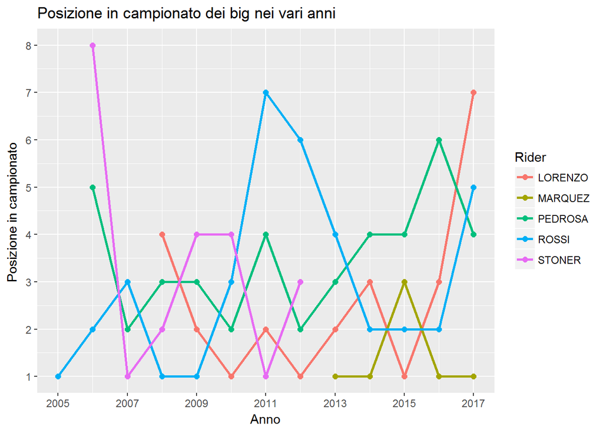

```r
piloti_big=piloti%>%filter(piloti$Rider=="ROSSI"| piloti$Rider=="LORENZO"| piloti$Rider=="STONER"| piloti$Rider=="PEDROSA"| piloti$Rider=="MARQUEZ")
ggplot(piloti_big,aes(x=piloti_big$Anno,y=piloti_big$Posizione, col=piloti_big$Rider))+
  geom_point(size=2)+
  geom_line(size=1)+
  scale_y_continuous("Posizione in campionato ", breaks=seq(0,10, by=1))+
  scale_x_continuous("Anno", breaks=seq(2005,2017, by=2))+
  labs(title="Posizione in campionato dei big nei vari anni", col="Rider")
```

```r
giri_big=giri%>%filter(giri$Rider=="ROSSI"| giri$Rider=="LORENZO"| giri$Rider=="STONER"| giri$Rider=="PEDROSA"| giri$Rider=="MARQUEZ")
```

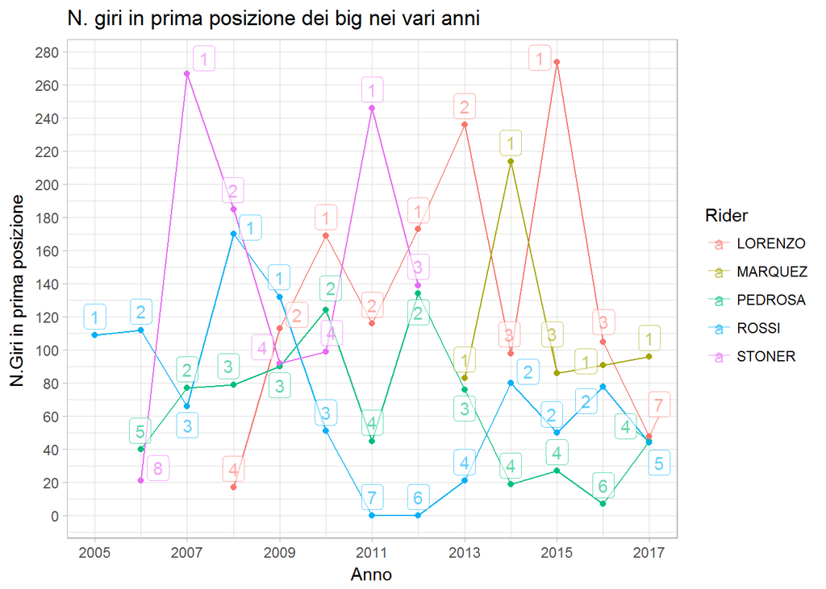

```r
ggplot(giri_big,aes(x=giri_big$Anno,y=giri_big$`Giri in prima posizione`, col=giri_big$Rider))+
  geom_point()+
  geom_line()+
  scale_y_continuous("N.Giri in prima posizione ", breaks=seq(0,300, by=20))+
  theme_light()+
  scale_x_continuous("Anno", breaks=seq(2005,2017, by=2))+
  labs(title="N. giri in prima posizione dei big nei vari anni", col="Rider")+
   ggrepel::geom_label_repel(aes(label=giri_big$Posizione),giri_big,nudge_y = 2, alpha = 0.6)
```

Tra i big si evince che chi effettua tanti giri in prima posizione tendenzialmente ricopre una posizione prestigiosa in campionato.

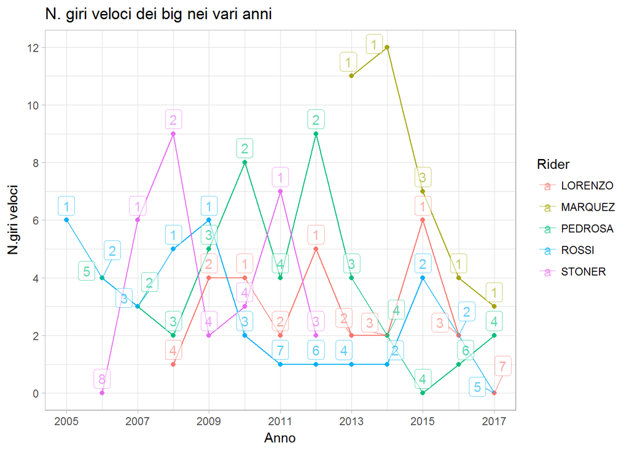

```r
ggplot(giri_big,aes(x=giri_big$Anno,y=giri_big$`Giri veloci`, col=giri_big$Rider))+
  geom_point()+
  geom_line()+
  scale_y_continuous("N.giri veloci", breaks=seq(0,16, by=2))+
  theme_light()+
  scale_x_continuous("Anno", breaks=seq(2005,2017, by=2))+
  labs(title="N. giri veloci dei big nei vari anni", col="Rider")+
   ggrepel::geom_label_repel(aes(label=giri_big$Posizione),giri_big,nudge_y = 0.5, alpha = 0.6)
```

Attraverso il grafico viene dimostrata la tesi che il numero di giri veloci non è legata alla posizione in classifica: infatti si può notare che nel 2008 Stoner arrivato secondo in classifica campionato, ha fatto quasi il doppio (9) di giri veloci rispetto a Rossi (5 giri veloci) che ha vinto il campionato.

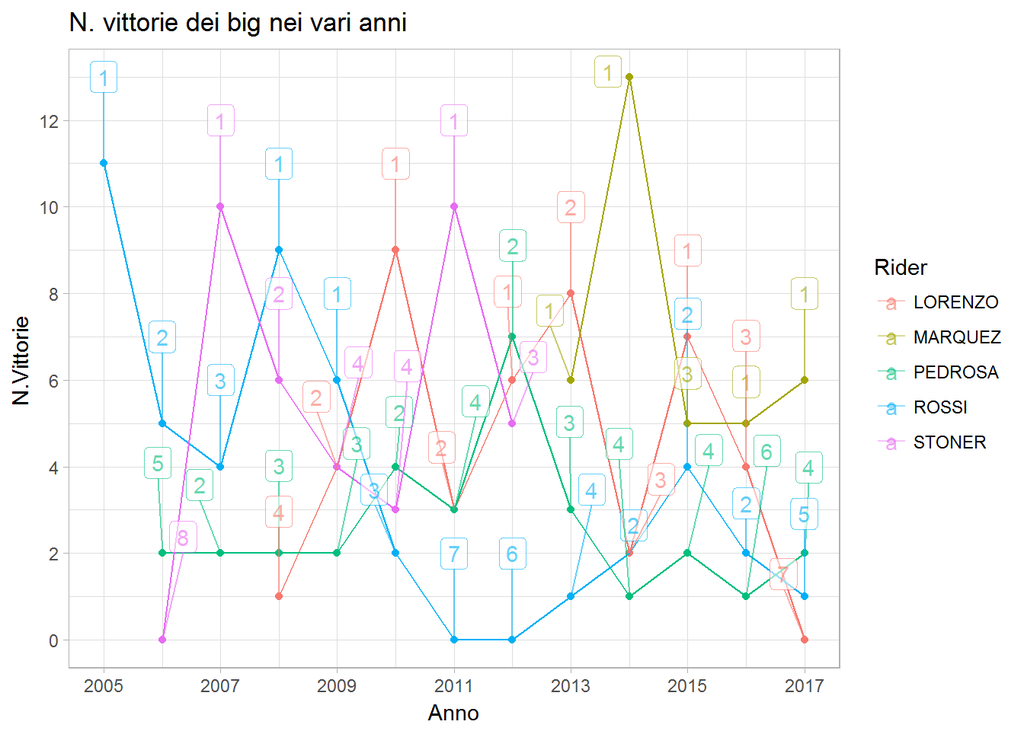

```r
ggplot(giri_big,aes(x=giri_big$Anno,y=giri_big$`N. Vittorie`, col=giri_big$Rider))+
  geom_point()+
  geom_line()+
  scale_y_continuous("N.Vittorie ", breaks=seq(0,14, by=2))+
  theme_light()+
  scale_x_continuous("Anno", breaks=seq(2005,2017, by=2))+
  labs(title="N. vittorie dei big nei vari anni", col="Rider")+
  ggrepel::geom_label_repel(aes(label=giri_big$Posizione),giri_big,nudge_y = 2, alpha = 0.6)
```

Dopo questo grafico viene sottolineato che il più forte non è colui che effettua il più alto numero di vittorie, infatti nel 2012 e nel 2013 il vice campione del mondo ha ottenuto un numero maggiore di primi posti rispetto al primo in classifica.

## 4. Diventare campione del mondo della MotoGP vuol dire essere realmente il pilota più forte della stagione?

Attraverso l’analisi è stato dimostrato che un pilota viene definito “forte” se ottiene dei buoni piazzamenti sul podio. Con questa analisi si metteranno in relazione i piazzamenti del campione e del vice campione di ogni stagione.

```r
#correlazione qualifica- risultato gara per i campioni
q=prova%>%filter(prova$Posizione==1)
q[, 5] <- sapply(q[, 5], as.numeric)
q[, 6] <- sapply(q[, 6], as.numeric)
qsenza=q%>%filter(q$Qualifica !=0)
cor.test(qsenza$Qualifica,qsenza$Risultato)
```

```
##
##  Pearson's product-moment correlation
##
## data:  qsenza$Qualifica and qsenza$Risultato
## t = 3.4341, df = 229, p-value = 0.0007057
## alternative hypothesis: true correlation is not equal to 0
## 95 percent confidence interval:
##  0.09493707 0.34064977
## sample estimates:
##       cor
## 0.2213028
```

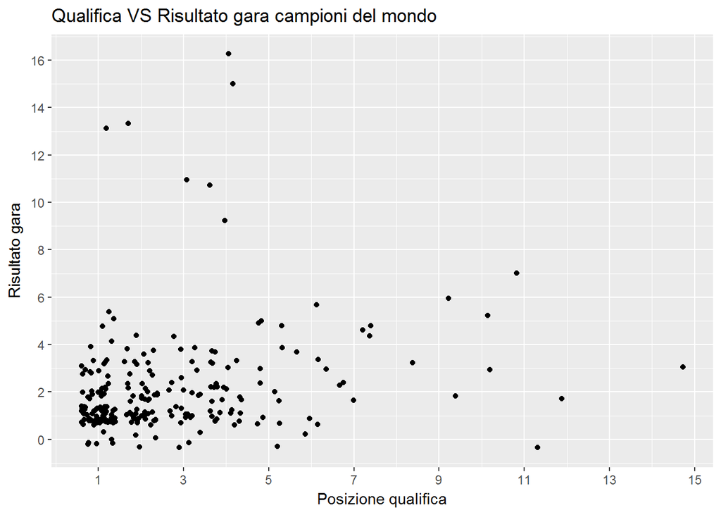

```r
#relazione generale qualifica-risultato
ggplot(data=qsenza)+
  geom_point(aes(x=qsenza$Qualifica,y=qsenza$Risultato),position = "jitter")+
  scale_x_continuous("Posizione qualifica",breaks=seq(1,20,by=2))+
  scale_y_continuous("Risultato gara",breaks=seq(0,20,by=2))+
  labs(title="Qualifica VS Risultato gara campioni del mondo")
```

La nuvola di punti in basso a sinistra rende evidente che il campione del mondo normalmente consegue buone qualifiche e realizza dei buoni piazzamenti.

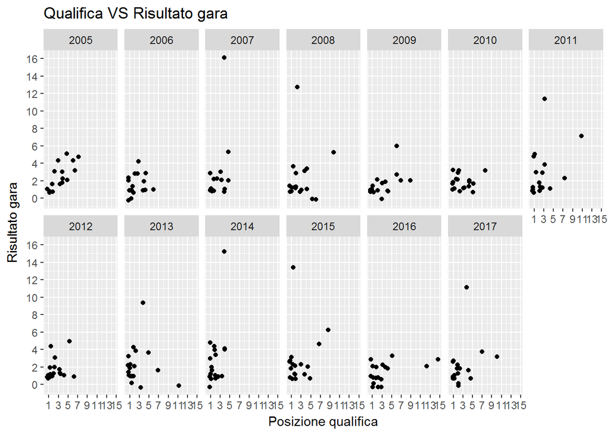

```r
#relazione qualifica-risultato specifica per anno
  ggplot(data=qsenza,aes(x=qsenza$Qualifica,y=qsenza$Risultato))+
    geom_point( position="jitter")+
    scale_y_continuous("Risultato gara", breaks=seq(0,20, by=2))+
    scale_x_continuous("Posizione qualifica", breaks=seq(1,25,by=2))+
    labs(title="Qualifica VS Risultato gara")+
    facet_wrap(~ qsenza$Anno, ncol=7)
```

Tuttavia nell’arco del campionato il campione del mondo può avere significative discrepanze di posizionamenti (barra lunga) rispetto ai risultati del secondo in campionato (pallini).

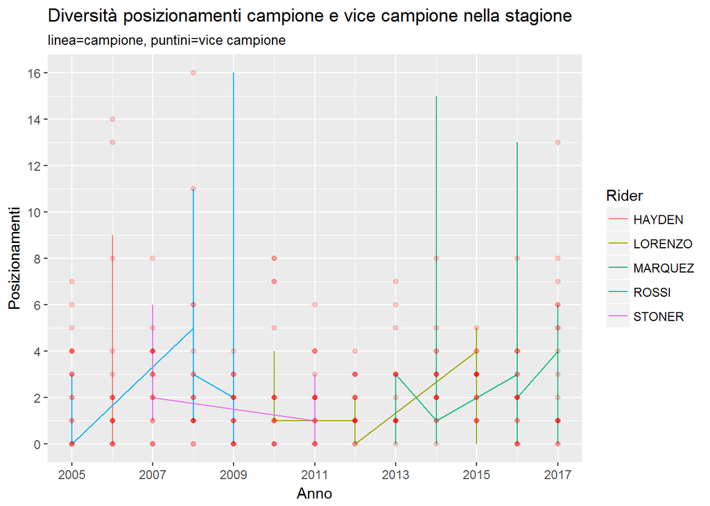

```r
vice=prova%>%filter(prova$Posizione==2)
vice[, 5] <- sapply(vice[, 5], as.numeric)
vice[, 6] <- sapply(vice[, 6], as.numeric)

#Diversità piazzamenti campione e vice campione del mondo
ggplot()+
  geom_line(aes(x=q$Anno,y=q$Risultato, col=q$Rider))+
  geom_point(aes(x=vice$Anno,y=vice$Risultato),alpha=0.2, col="red")+
  scale_x_continuous("Anno", breaks=seq(2005,2017,by=2))+
  scale_y_continuous("Posizionamenti", breaks=seq(0,16,by=2))+
  labs(title="Diversità posizionamenti campione e vice campione nella stagione",subtitle="linea=campione, puntini=vice campione" ,col="Rider")
```

In diversi anni si nota che il vice campione del mondo pur avendo ottenuto dei risultati maggiormente concentrati in determinate posizioni rispetto al primo in classifica, non è riuscito a distinguersi e ottenere la vittoria del campionato.

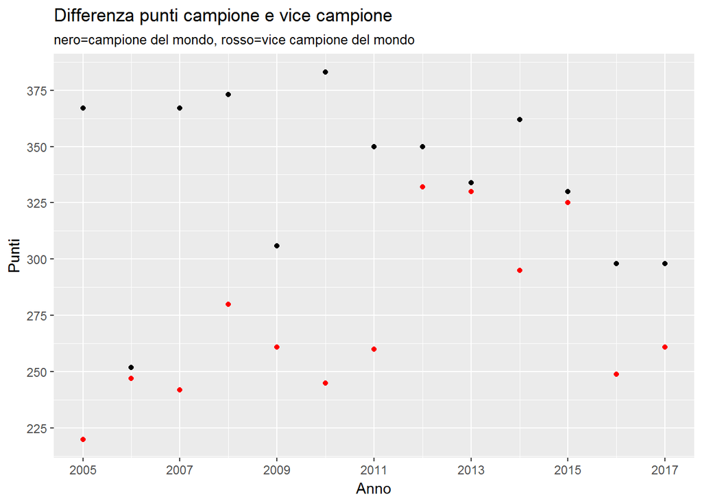

```r
giri_c_v=giri%>%filter(giri$Posizione==1| giri$Posizione==2)
ggplot()+
  geom_point(aes(x=giri_c_v$Anno,y=giri_c_v$Punti),col=giri_c_v$Posizione)+
  scale_x_continuous("Anno", breaks=seq(2005,2017,by=2))+
  scale_y_continuous("Punti", breaks=seq(0,400,by=25))+
  labs(title="Differenza punti campione e vice campione", subtitle="nero=campione del mondo, rosso=vice campione del mondo")
```

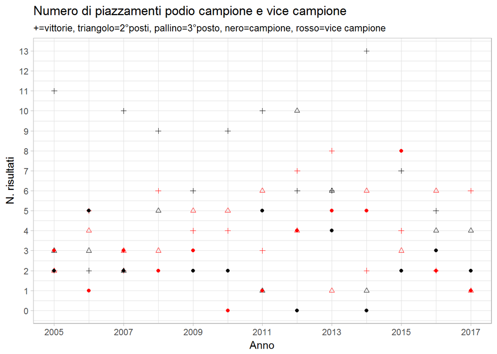

```r
ggplot()+
  geom_point(aes(x=giri_c_v$Anno,y=giri_c_v$`N. Vittorie`),col=giri_c_v$Posizione,shape=3)+
  geom_point(aes(x=giri_c_v$Anno,y=giri_c_v$`2 posti`), col=giri_c_v$Posizione, shape=2)+
  geom_point(aes(x=giri_c_v$Anno,y=giri_c_v$`3 posti`), col=giri_c_v$Posizione)+
  scale_x_continuous("Anno", breaks=seq(2005,2017,by=2))+
  scale_y_continuous("N. risultati", breaks=seq(0,16,by=1))+
  theme_light()+
  labs(title="Numero di piazzamenti podio campione e vice campione", subtitle="+=vittorie, triangolo=2°posti, pallino=3°posto, nero=campione, rosso=vice campione")
```

## 5. Esiste una relazione tra la nazionalità del vincitore e il circuito? C’è una relazione tra il circuito e la marca della moto vincitrice?

Per poter rispondere alla domanda va caricato il dataset vincitori2.0.

```r
vincitori2 <- read_excel("Dataset_vincitori2.0.xlsx")
```

Nel dataset viene escluso il nome esteso del circuito (colonna 2) che ripete l’informazione contenuta nella sigla univoca del circuito (colonna 3). La sigla identificativa è stata tradotta con un valore numerico (vedi “Nomenclatura.txt”).

```r
vincitori2=vincitori2[,-2]
```

```r
#Verifica della chiave primaria
vincitori2%>%
  count(Stagione, `Sigla circuito`)%>%
  filter(n>1)
```

```
## # A tibble: 0 x 3
## # ... with 3 variables: Stagione <dbl>, `Sigla circuito` <dbl>, n <int>
```

° C’è relazione tra la nazionalità del vincitore e il luogo in cui è ubicata la gara?

```r
cor.test(vincitori2$Paese, vincitori2$Nazionalità)
```

```
##
##  Pearson's product-moment correlation
##
## data:  vincitori2$Paese and vincitori2$Nazionalità
## t = 0.54821, df = 228, p-value = 0.5841
## alternative hypothesis: true correlation is not equal to 0
## 95 percent confidence interval:
##  -0.09351532  0.16486680
## sample estimates:
##        cor
## 0.03628209
```

Si nota che le due variabili risultano indipendenti, anche perchè le gare del Motomondiale vengono disputate in vari Paesi del mondo mentre le nazionalità dei piloti vincitori sono poche, principalmente risultano Spagnoli, Italiani, Australiani ed Americani.

°C’è relazione tra costruttore e circuito?

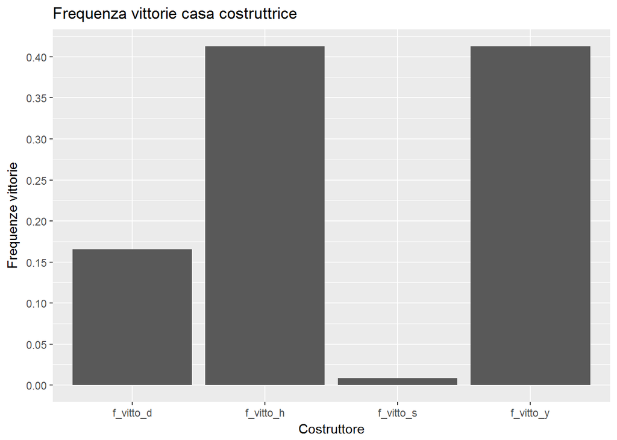

```r
#_vitto=aggregate(prova$Risultato==1 ~ prova$Rider, data = prova, sum)
honda=aggregate(vincitori2$Costruttore==1~vincitori2$`Sigla circuito`, data = vincitori2, sum)
ducati=aggregate(vincitori2$Costruttore==2~vincitori2$`Sigla circuito`, data = vincitori2, sum)
suzuki=aggregate(vincitori2$Costruttore==3~vincitori2$`Sigla circuito`, data = vincitori2, sum)
yamaha=aggregate(vincitori2$Costruttore==4~vincitori2$`Sigla circuito`, data = vincitori2, sum)
f_vitto_h=sum(honda$`vincitori2$Costruttore == 1`)/230
f_vitto_d=sum(ducati$`vincitori2$Costruttore == 2`)/230
f_vitto_s=sum(suzuki$`vincitori2$Costruttore == 3`)/230
f_vitto_y=sum(yamaha$`vincitori2$Costruttore == 4`)/230
freq_casa=data.frame(f_vitto_h,f_vitto_d, f_vitto_s, f_vitto_y)
freq_casa=freq_casa%>%gather('f_vitto_h','f_vitto_d','f_vitto_s','f_vitto_y',key="Case", value="Frequenze")
ggplot()+
  geom_bar(aes(x=freq_casa$Case, y=freq_casa$Frequenze),stat="identity")+
  scale_y_continuous("Frequenze vittorie",breaks=seq(0,0.45,by=0.05))+
  labs(title="Frequenza vittorie casa costruttrice")+
  xlab("Costruttore")
```

E’ da tenere presente che la frequenza di vittoria della casa costruttrice “Suzuki” non è possibile confrontarla con le altre, poichè per alcune stagioni (2012,2013 e 2014) non ha preso parte al mondiale.

```r
cor.test(vincitori2$Costruttore,vincitori2$`Sigla circuito`)
```

```
##
##  Pearson's product-moment correlation
##
## data:  vincitori2$Costruttore and vincitori2$`Sigla circuito`
## t = -3.126, df = 228, p-value = 0.002002
## alternative hypothesis: true correlation is not equal to 0
## 95 percent confidence interval:
##  -0.32359869 -0.07534371
## sample estimates:
##        cor
## -0.2027264
```

```r
f_case_tot=honda%>%mutate(N_Ducati=ducati$`vincitori2$Costruttore == 2`)
f_case_tot=f_case_tot%>%mutate(N_Suzuki=suzuki$`vincitori2$Costruttore == 3`)
f_case_tot=f_case_tot%>%mutate(N_Yamaha=yamaha$`vincitori2$Costruttore == 4`)
f_case_tot=f_case_tot%>%mutate(N_Honda=honda$`vincitori2$Costruttore == 1`)
names(f_case_tot)[names(f_case_tot)=="vincitori2$`Sigla circuito`"]<- "Sigla"
f_case_tot=f_case_tot[,-2]
```

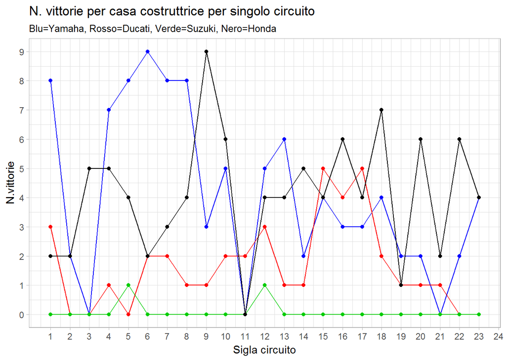

```r
ggplot()+
  geom_line(aes(x=f_case_tot$Sigla,y=f_case_tot$N_Yamaha),col=4)+
  geom_point(aes(x=f_case_tot$Sigla,y=f_case_tot$N_Yamaha),col=4)+
  geom_line(aes(x=f_case_tot$Sigla,y=f_case_tot$N_Ducati),col=2)+
  geom_point(aes(x=f_case_tot$Sigla,y=f_case_tot$N_Ducati),col=2)+
  geom_line(aes(x=f_case_tot$Sigla,y=f_case_tot$N_Suzuki),col=3)+
  geom_point(aes(x=f_case_tot$Sigla,y=f_case_tot$N_Suzuki),col=3)+
  geom_line(aes(x=f_case_tot$Sigla, y=f_case_tot$N_Honda),col=1)+
  geom_point(aes(x=f_case_tot$Sigla, y=f_case_tot$N_Honda),col=1)+
  scale_x_continuous("Sigla circuito", breaks=seq(1,24,by=1))+
  scale_y_continuous("N.vittorie", breaks=seq(0,12,by=1))+
  theme_light()+
  labs(title="N. vittorie per casa costruttrice per singolo circuito", subtitle="Blu=Yamaha, Rosso=Ducati, Verde=Suzuki, Nero=Honda")
```

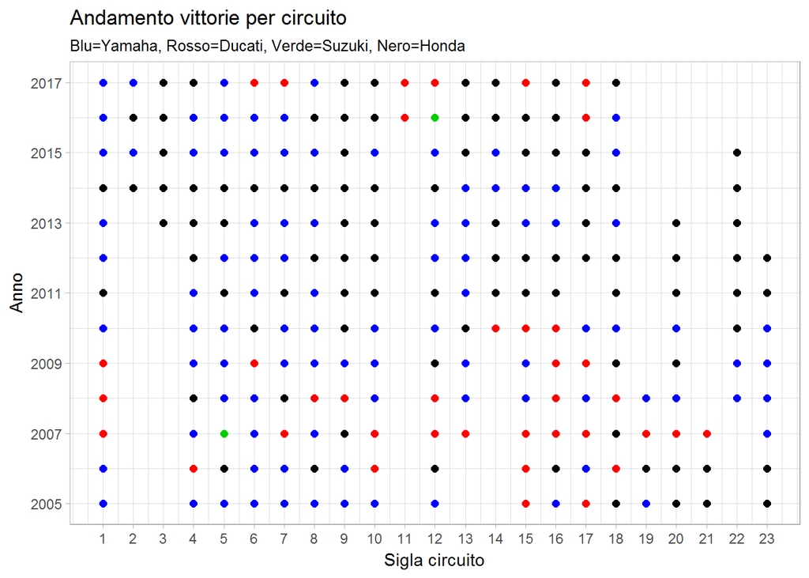

```r
ggplot()+
  geom_point(aes(x=vincitori2$`Sigla circuito`,y=vincitori2$Stagione),col=vincitori2$Costruttore,size=2)+
  scale_x_continuous("Sigla circuito", breaks=seq(1,23,by=1))+
  scale_y_continuous("Anno", breaks=seq(2005,2017,by=2))+
  theme_light()+
  labs(title="Andamento vittorie per circuito", subtitle="Blu=Yamaha, Rosso=Ducati, Verde=Suzuki, Nero=Honda")
```

Osservando i dati emerge che in certe piste c’è un predominio di una determinata casa costruttrice che continua da diverse stagioni, come si può notare per quanto riguarda Honda nel circuito 3 e 9. Questo predominio di una scuderia può essere legato a molti fattori, quali:  
1. Le caratteristiche del tracciato (es.la pista ha lunghi rettilinei, curve particolari, o sul medesimo lato).  
2. La capacità di interpretazione del circuito da parte del pilota.

## 1.5 Conclusioni

In conclusione attraverso lo studio si è scoperto che tra qualifica e risultato della gara c’è un legame: la buona posizione in qualifica influisce sul risultato della gara. Tuttavia si è notato che il pilota candidato a vincere il campionato non può basarsi unicamente sul numero di vittorie che ottiene, ma deve collezionare una serie rilevante di piazzamenti sul podio.  
L’ottenimento di diversi buoni risultati determina la posizione in campionato del pilota ma essa non è legata al numero di giri che effettua in prima posizione, o al numero di giri veloci o alle pole position che ottiene, anche se questi tre elementi sono tra di loro fortemente legati. Infatti, non necessariamente il primo in classifica risulta colui che effettua il maggior numero di giri in prima posizione, o il maggior numero di giri veloci. La rilevanza dei piazzamenti sul podio si riscontra anche quando si confrontano i risultati del campione e del vice campione del mondo.  
Risulta ininfluente la relazione intercorrente tra la nazionalità del pilota vincitore e l’ubicazione del circuito: si è scoperto che questa non sussiste perchè le gare del Motomondiale vengono svolte in diversi continenti mentre le nazionalità dei piloti sono limitate. Al contrario si è riscontrato che in certe piste c’è il predominio di una casa costruttrice che trova il circuito più congegnale alle caratteristiche della moto e/o del pilota.  
Pertanto,  
> l’importante non è vincere ma partecipare! (Pierre de Coubertin)

[figure not shown]